# Introduction to K Nearest Neighbors (KNN)

Dr. Gilbert

August 05, 2023

**Purpose:** In this notebook we introduce the *$k$ nearest neighbors* classifier. In particular, we note that

- the $k$ in the name of the classifier indicates the number of *voting* neighbors when a prediction is made.
- *nearest neighbors* is a distance-based model.
  - Numerical predictors should be scaled in order to use this class of model.
  - Categorical predictors are not supported by *nearest neighbor* models without significant assumptions made regarding relationships between their levels.
  - *Nearest neighbor* models suffer greatly from *the curse of dimensionality*.

## The Big Idea

A *nearest neighbor* model assumes that observations are most like those nearest to them. The nearest neighbor model makes predictions on a new observation in the following way:

1. Identify the $k$ observations which are *closest* to the new observation. (**Note:** It is possible to use a variety of distance metrics, not just the Euclidean metric.)
2. Allow those $k$ “nearest neighbors” to vote on the response for the new observation.

The following visual may be helpful.

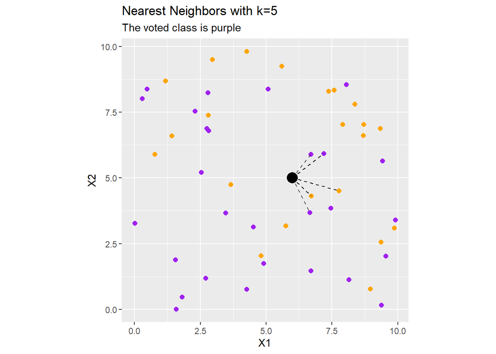

## About KNN

Given the two stage process, you might note that a *nearest neighbor* model isn’t actually *trained*. The “locations” and responses for the training data are simply stored, and when a prediction is to be made, the algorithm is run. This has several implications.

- The *nearest neighbor* approach is not a *model*, it is really an algorithm to obtain predictions.
- The *nearest neighbor* approach is expensive in terms of memory requirements because the entire “training” set must be stored in perpetuity.
- The *nearest neighbor* approach is expensive in terms of compute time because the algorithm must be run in full every time a new prediction is to be made.
- The *nearest neighbors* algorithm is non-parametric and no functional form is estimated.
  - This means that *nearest neighbors* does not result in an interpretable model like linear regression, logistic regression, decision trees, or others do.

Where *nearest neighbor* approaches have the drawbacks cited above, they do have some significant advantages. In particular, they can approximate very complex decision boundaries. We can also *tune* the parameter $k$ in order to obtain an appropriately flexible boundary.

## Regression and Classification

It is worth noting that $k$ *nearest neighbors* can be used in both the *classification* and *regression* settings.

- For *classification*, each neighbor provides a vote for the class of the new observation and the plurality wins.
- For *regression*, the value of the response for each of the nearest neighbors are averaged to obtain the predicted response for the new observation.

## How to Implement in `{tidymodels}`

A KNN classifier is a model class (that is, a model `spec`*ification*). We define our intention to build a KNN classifier using

```r
knn_clf_spec <- nearest_neighbor() %>%
  set_engine("kknn") %>%
  set_mode("classification")
```

K Nearest Neighbors can be used for *both* regression and classification. For this reason, the line to `set_mode()` is required when declaring the model specification. The line to `set_engine()` above is unnecessary since `kknn` is the default engine. There are other available engines though.

#### Hyperparameters and Other Extras

Like other model classes, nearest neighbors have *tunable hyperparameters*. They are

- `neighbors`, which determines the number of *voting neighbors* to determine the model’s ultimate prediction on a new observation.
  - Remember, the fewer voting neighbors, the more flexible the model is.
- `weight_func` determines how we’ll compute distances between observations. More than just Euclidean distance (`"rectangular"`) are available.

You can see the full `{parsnip}` documentation for `nearest_neighbor()` [here](https://parsnip.tidymodels.org/reference/nearest_neighbor.html).

## How to Implement in `{sklearn}`

A KNN classifier is a model class. We first import `KNeighborsClassifier` from `sklearn.neighbors` and then create an instance of the model constructor using:

```r
from sklearn.neighbors import KNeighborsClassifier

knn_clf = KNeighborsClassifier()
```

Note that, since KNN is a distance-based model, all numerical predictors should be scaled. Additionally, using categorical predictors with KNN models makes assumptions that aren’t well-supported. That being said, we can keep calm and cross-validate to determine whether using them improves model performance.

#### Hyperparameters and Other Extras

Like other model classes, nearest neighbors have *tunable hyperparameters*. The ones you are most likely to utilize are

- `n_neighbors`, which determines the number of *voting neighbors* to determine the model’s ultimate prediction on a new observation. The default is 5.
  - Remember, the fewer voting neighbors, the more flexible the model is.
- `metric` determines how we’ll compute distances between observations. More than just Euclidean distance are available.
  - `p` is an additional parameter associated with the metric which determines the powers used in the distance calculation. For example if `p = 2` corresponds to Euclidean distance $\displaystyle{\sqrt{d_1^2 + d_2^2 + \cdot + d_k^2}}$. The `p` parameter governs the powers and the order of the root used.
- `weights` determines whether votes will be weighted or not. The possible values are `uniform` (all votes are equal) or `distance` (closer neighbors have more powerful votes).

You can see the full `{sklearn}` documentation for `KNeighborsClassifier()` [here](https://scikit-learn.org/stable/modules/generated/sklearn.neighbors.KNeighborsClassifier.html).

## Summary

In this notebook we learned a bit about the $k$ *nearest neighbors* algorithm. In particular, we saw that this is a distance-based algorithm which can be used for either regression or classification. We also saw that it is a non-parametric method which does not result in a *model* and cannot be interpreted. The algorithm is run every time a new prediction is to be made, making *nearest neighbors* an expensive algorithm in terms of both space and time. While *nearest neighbors* has its drawbacks it is a powerful technique which can fit very complex decision boundaries in the classification setting and can approximate complex functions well in the regression setting. *Nearest neighbors* also makes no distribution assumptions about the underlying data – only that observations are most similar to those around them.

We’ll implement $k$ *nearest neighbors* using the `nearest_neighbor()` model class from `{tidymodels}` in our next class meeting.